# Números complexos: Representação polar

Sabemos que, dado dois números complexos $z$ e $w$: $$zw=(a+ib)(c+id)=(ac-bd)+i(ad+bc)$$ $$|z|^2=(a^2+b^2)=zz^*=z\bar{z}$$

No plano complexo, como mostrado na figura abaixo temos, com $\theta$ sendo um número real, as seguintes relações:

$$|z|^2=(a^2+b^2)$$ $$|z|=r\ge0$$

$$\theta \textrm{: é o argumento de }z$$ $$\mathfrak{Re}z=|z|\cos\theta$$ $$\mathfrak{Im}z=|z|\textrm{sen}\theta$$ $$z=r(\cos\theta + i \textrm{sen}\theta)$$

- Para o número complexo de valor absoluto 1, temos que:
- $$|\cos\theta + i \textrm{sen}\theta|=1$$
- Assim um número complexo de módulo unitário é $z_1=\cos\theta_1 + i \textrm{sen}\theta_1$ ou $z_2=\cos\theta_2 + i \textrm{sen}\theta_2$

### Onde $\theta$ e $r$ são dados pela figura abaixo:

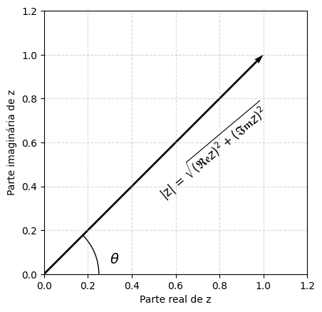

## Fica fácil realizar operações de produto e divisão (para o caso de $|z|=1$)

$$z_1z_2=(\cos\theta_1 + i \textrm{sen}\theta_1)(\cos\theta_2 + i \textrm{sen}\theta_2)$$ utilizando $\cos(A+B)=\cos(A)\textrm{sen}(B)-\textrm{sen}(A)\textrm{sen}(B)$ $$z_1z_2=\cos(\theta_1+\theta_2) + i \textrm{sen}(\theta_1+\theta_2)$$ De forma similar temos: $$\frac{z_1}{z_2}=\cos(\theta_1-\theta_2) + i \textrm{sen}(\theta_1-\theta_2)$$

- Para o número complexo de valor absoluto 1 usamos a seguinte notação:
- $z=e^{i\theta}=\cos\theta + i \textrm{sen}\theta$ e é fácil mostrar que o símbolo $e^{0}=1$

Para um número complexo qualquer temos:

- $z=re^{i\theta}=r(\cos\theta + i \textrm{sen}\theta)$

  Fica fácil observar que o produto é: $$z_1z_2=r_1r_2\left[\cos(\theta_1+\theta_2) + i \textrm{sen}(\theta_1+\theta_2)\right]=r_1r_2e^{i(\theta_1+\theta_2)}$$ $$z_1z_2z_3=r_1r_2r_3\left[\cos(\theta_1+\theta_2+\theta_3) + i \textrm{sen}(\theta_1+\theta_2+\theta_3)\right]=r_1r_2r_3e^{i(\theta_1+\theta_2+\theta_3)}$$ $$z_1z_2\cdots z_n=r_1r_2\cdots r_ne^{i(\theta_1+\theta_2+\cdots +\theta_n)}=\left(\prod_{k=1}^{n}r_k\right)e^{i\sum_{k=1}^n \theta_k}$$

E também $z^{-1}=r^{-1}e^{-i\theta}$, pois, sabemos que $zz^{-1}=1=rr^{-1}e^{i\theta}e^{-i\theta}=e^{i\theta-i\theta}=e^{0}=1$. Verifique!

Assim, para qualquer inteiro n temos: $$\textrm{se }z=r e^{i\theta} \textrm{ é um número complexo, então: }z^n= r(\cos\theta+i\textrm{sen}\theta )r(\cos\theta+i\textrm{sen}\theta )\cdots=r^n(\cos\theta+i\textrm{sen}\theta )^n=(rr\cdots)e^{i\theta+\theta+\cdots}=r^ne^{in\theta}$$ Assim se $n$ é um número natural e $\theta$ é real e usando $r=1$, obtemos: $$z^n=(\cos\theta + i \textrm{sen}\theta)^n=e^{in\theta}$$ e usando a expressão para o produto de números polares (soma dos ângulos) $$e^{in\theta}=zzzzz\cdots=[\cos(\theta+\theta+\cdots) + i \textrm{sen }(\theta+\theta+\cdots)]=(\cos n\theta + i \textrm{sen }n\theta)$$

Chegamos na fórmula de Moivre:

$$(\cos\theta + i \textrm{sen}\theta)^n=(\cos n\theta + i \textrm{sen}n\theta)$$

### Desigualdades

Dados os números complexos $z$ e $w$, temos as seguintes desigualdades:

- $|\mathfrak{Re}z|\le |z|$, e $|\mathfrak{Im}z| \le |z|$;
- $|z + w| \le |z| + |w|$ (Desigualdade triangular);
- $||z| - |w|| \le |z - w|$

# Raízes

Introduzimos números complexos como ferramenta para solucionar equações polinomiais. Por exemplo a equação $z^n = 1$.

- Fazendo $z = r e^{i\theta} \rightarrow r^n e^{in\theta} =1$
- Assim $cos (n\theta) =1$ e $\mathrm{sen}(n\theta)=0$.
- As raízes para estas equações trigonométricas possuem argumento $0+\frac{2k\pi}{n}, k=0,1,...,n-1$ e módulo $\sqrt[n]1$.
- Temos $n$ números complexos distintos os quais representam as raízes da equação dada e são escrito como:
- $$e^{\frac{2k\pi i}{n}},~k=0,1,...,n-1$$
- Escrevendo $$w=e^{\frac{2\pi i}{n}},~\rightarrow~w^k=e^{\frac{2k\pi i}{n}} ~k=0,1,...,n-1$$
- Temos as seguintes possíveis raízes:

| $k$ | Forma exponencial | Forma trigonométrica | Forma algébrica |
| --- | --- | --- | --- |
| 0 | $e^{i\frac{2\pi\cdot 0}{6}} = e^{i0}$ | $\cos(0)+i\sin(0)$ | $1$ |
| 1 | $e^{i\frac{2\pi}{6}} = e^{i\frac{\pi}{3}}$ | $\cos\!\left(\tfrac{\pi}{3}\right)+i\sin\!\left(\tfrac{\pi}{3}\right)$ | $\dfrac{1}{2} + i\,\dfrac{\sqrt{3}}{2}$ |
| 2 | $e^{i\frac{4\pi}{6}} = e^{i\frac{2\pi}{3}}$ | $\cos\!\left(\tfrac{2\pi}{3}\right)+i\sin\!\left(\tfrac{2\pi}{3}\right)$ | $-\dfrac{1}{2} + i\,\dfrac{\sqrt{3}}{2}$ |
| 3 | $e^{i\frac{6\pi}{6}} = e^{i\pi}$ | $\cos(\pi)+i\sin(\pi)$ | $-1$ |
| 4 | $e^{i\frac{8\pi}{6}} = e^{i\frac{4\pi}{3}}$ | $\cos\!\left(\tfrac{4\pi}{3}\right)+i\sin\!\left(\tfrac{4\pi}{3}\right)$ | $-\dfrac{1}{2} - i\,\dfrac{\sqrt{3}}{2}$ |
| 5 | $e^{i\frac{10\pi}{6}} = e^{i\frac{5\pi}{3}}$ | $\cos\!\left(\tfrac{5\pi}{3}\right)+i\sin\!\left(\tfrac{5\pi}{3}\right)$ | $\dfrac{1}{2} - i\,\dfrac{\sqrt{3}}{2}$ |

- Veja o gráfico para as 6 raízes, observe se o argumento não está no intervalo $-\pi\le Arg(z)\le\pi$, se não estiver coloque!
- Observe o nosso número $w$ como definido acima, e veja como seria o conjugado $w^*=\bar w$.

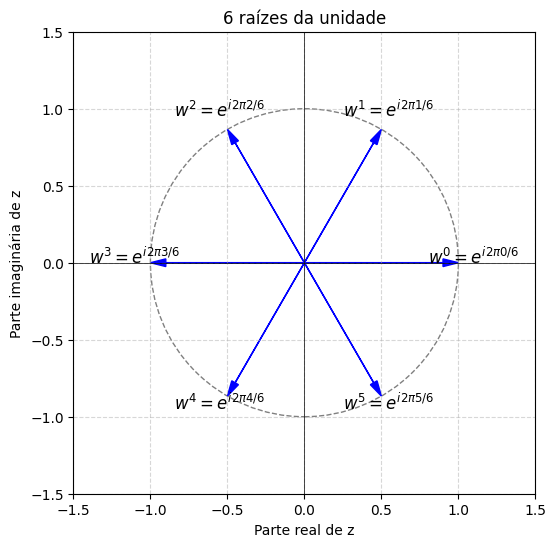

### Para o caso das 4 raízes da unidade

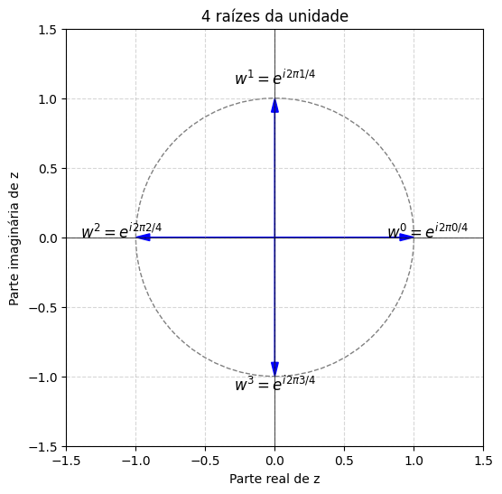

## Para as 8 raízes da unidade

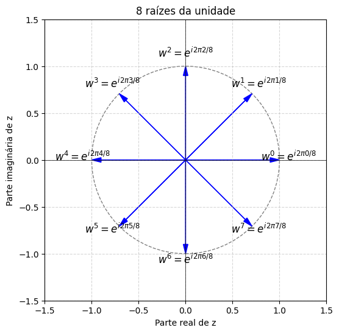

```
E assim em frente
```

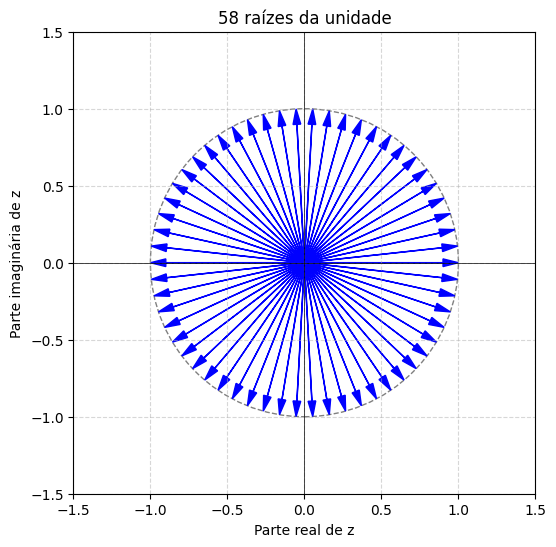

# Caso Geral

- se $z=re^{i\theta}$ temos que $z^n=re^{in\phi},~\phi=n\theta\pm2\pi k$
- Temos que $$w_0=\sqrt[n]{r}\left(\cos\frac{\theta}{n}+i\mathrm{sen}\frac{\theta}{n}\right)$$ é n-ésima raíz de $z$
- Isto decorre de: $$w_0^n=re^{i\theta}=z$$
- $$w_0=\sqrt[n]{r}e^{i\theta/n}$$
- $$w_1=\sqrt[n]{r}e^{i(\theta+2\pi)/n}$$
- $$w_k=\sqrt[n]{r}e^{i(\theta+2\pi k)/n}$$
- Basicamente escrevemos $z$ na forma polar e encontramos suas raízes usando a expressão acima.

### Exemplo

- dDado $z=i$, encontre as três raízes cubicas de z.
- Temos que resolver $w^3=i$, escrevemos na forma polar $i=e^{i\pi/2}$
- logo usando a expressão acima obtemos $w_k=\sqrt[3]{1}e^{i\left(\frac{\pi}{2}+2k\pi\right)/3}$
- Fica como treino obter k=0, k=1 e k=2, basta reescrever o simbolo $e^z$ na forma polar com cos e sen, [Veja cap 1 do livro Dennis, onde se usa a forma polar cos +isen]

### Geometria

Conjuntos de Pontos no Plano Complexo

## Círculos

Seja $z_0 = x_0 + i y_0$.  
Como

$ |z - z_0| = \sqrt{(x - x_0)^2 + (y - y_0)^2} $

representa a distância entre os pontos (z = x + iy) e (z_0 = x_0 + iy_0), os pontos (z) que satisfazem

$ |z - z_0| = \rho, \quad \rho > 0 $

estão em um **círculo de raio (\rho)** centrado em (z_0).

**Exemplo 1 – Dois Círculos**

1. $|z| = 1$ → círculo unitário centrado na origem.
2. $|z - 1 + 3i| = 5 \iff |z - (1 - 3i)| = 5$ → círculo de raio 5 centrado em (z_0 = 1 - 3i).

## Discos e Vizinhanças

- O conjunto $|z - z_0| \leq \rho$ → **disco fechado** de raio $\rho$, centrado em $z_0$.
- O conjunto $|z - z_0| < \rho$ → **vizinhança (aberta)** de $z_0$.
- O conjunto $0 < |z - z_0| < \rho$ → **vizinhança pontuada (ou deletada)** de $z_0$.

**Exemplos:**

- $|z| < 1$ → vizinhança da origem.
- $0 < |z| < 1$ → vizinhança deletada da origem.
- $|z - 3 + 4i| < 0.01$ → vizinhança de $3 - 4i$.
- $0 < |z - 3 + 4i| < 0.01$ → vizinhança deletada de $3 - 4i$.

## Conjuntos Abertos

- Um ponto $z_0$ é **interior** de um conjunto $S$ se existir uma vizinhança de $z_0$ contida em $S$.
- Se **todos os pontos** de $S$ são interiores, então $S$ é um **conjunto aberto**.

**Exemplo:**

- $\text{Re}(z) > 1$ → semi-plano direito, que é um conjunto aberto.

**Contraexemplo:**

- $\text{Re}(z) \geq 1$ não é aberto, pois pontos sobre a reta $x = 1$ não possuem vizinhança totalmente contida no conjunto.

**Exemplo 2 – Alguns conjuntos abertos:**

1. $\text{Im}(z) < 0$ → semi-plano inferior.
2. $-1 < \text{Re}(z) < 1$ → faixa vertical infinita.
3. $|z| > 1$ → exterior do círculo unitário.
4. $1 < |z| < 2$ → interior de um anel circular.

## Pontos de Fronteira, Interior e Exterior

- Um ponto $z_0$ é **de fronteira** se toda vizinhança de $z_0$ contém pontos de $S$ e de fora de $S$.
- A **fronteira** de $S$ é o conjunto de todos os seus pontos de fronteira.
- Pontos que não são interiores nem de fronteira → **pontos exteriores**.

Exemplo:

- Para $\text{Re}(z) \geq 1$, a reta $x = 1$ é fronteira.
- Para o disco $|z - i| \leq 2$, a circunferência $|z - i| = 2$ é fronteira.

## Anel

Se $0 < \rho_1 < \rho_2$, o conjunto

$$ \rho_1 < |z - z_0| < \rho_2 $$

é um **anel circular aberto** (região entre dois círculos concêntricos).

Se $\rho_1 = 0$ → vizinhança deletada de $z_0$.

## Domínios

- Um conjunto é **conexo** se quaisquer dois pontos podem ser unidos por uma linha poligonal contida no conjunto.
- Um **domínio** é um conjunto **aberto e conexo**.

Exemplo:

- $\text{Re}(z) \neq 4$ é aberto, mas não conexo (há dois lados separados pela reta $x = 4$).

## Regiões

- Uma **região** é qualquer conjunto de pontos no plano complexo que pode conter **todos, alguns ou nenhum** dos seus pontos de fronteira.
- Região aberta = não contém fronteira (ex.: vizinhança aberta).
- Região fechada = contém toda a fronteira (ex.: disco fechado $|z - z_0| \leq \rho$).
- **Discos pontuados**:
  - $0 < |z - z_0| \leq \rho$ → disco fechado sem o centro.
  - $0 < |z - z_0| < \rho$ → disco aberto sem o centro (igual a vizinhança deletada).

## Conjuntos Limitados

- **Limitado:** existe $R > 0$ tal que $|z| < R$ para todo $z \in S$.
  - Intuitivamente, $S$ pode ser contido dentro de um círculo de raio $R$ centrado na origem.
- Se isso não é possível → $S$ é **ilimitado**.

**Exemplos:**

- O anel $1 < |z| < 2$ é limitado.
- O semi-plano $\text{Re}(z) > 1$ é ilimitado.